# rixpress: Build Reproducible Analytical Pipelines with ‘Nix’

[figure not shown]

[figure not shown]

If you want to watch a 2-Minute video introduction, click the image below:

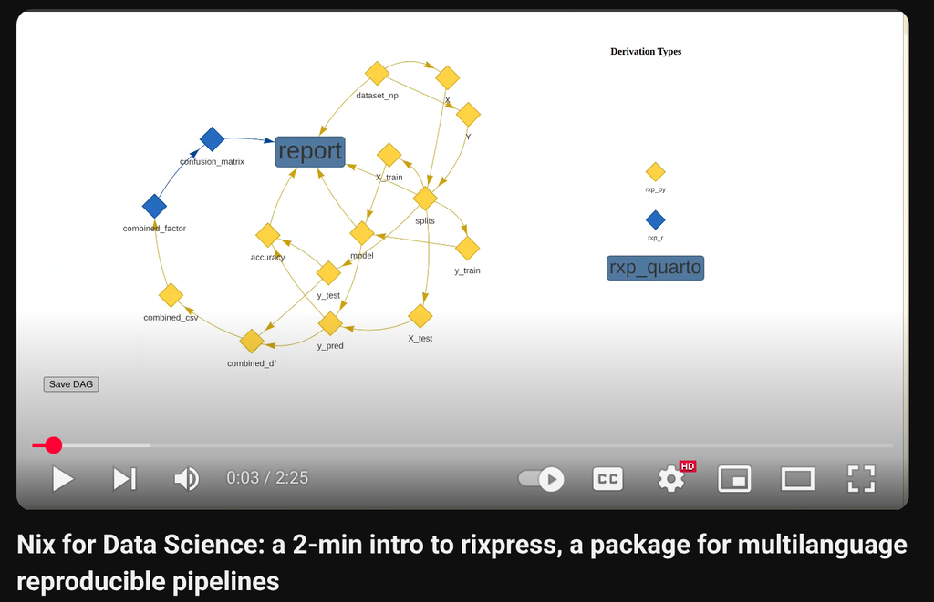

`rixpress` streamlines creation of *micropipelines* (small-to-medium, single–machine analytic pipelines) by expressing a pipeline in idiomatic R while delegating build orchestration, dependency management, and multi-language execution to the ‘Nix’ build system. It is inspired by the user experience of the `{targets}` package and builds on the `{rix}` package to obtain fully reproducible development/runtime environments.

Key ideas:

- Define pipeline *derivations* with concise `rxp_*()` helper functions.
- Seamlessly mix R, Python, Julia, Quarto / Markdown steps.
- Reuse hermetic environments (pinned system + language dependencies) defined via `{rix}` and a `default.nix`.
- Visualize and inspect the DAG; selectively read, load, or copy outputs.
- Export/import build artifacts to speed up CI or share results.

Here is what a basic pipeline looks like:

```r
library(rixpress)

list(
  rxp_r_file(
    mtcars,
    'mtcars.csv',
    \(x) (read.csv(file = x, sep = "|"))
  ),

  rxp_r(
    mtcars_am,
    filter(mtcars, am == 1)
  ),

  rxp_r(
    mtcars_head,
    head(mtcars_am)
  ),

  rxp_r(
    mtcars_tail,
    tail(mtcars_head)
  ),

  rxp_r(
    mtcars_mpg,
    select(mtcars_tail, mpg)
  ),

  rxp_qmd(
    page,
    "page.qmd"
  )
) |>
  rxp_populate()
```

## Contents

- Motivation
- Feature Highlights
- Organizing with Sub-Pipelines
- Examples
- Getting started
- Visualization
- Exporting / Importing Artifacts
- Contributing
- Scope
- Acknowledgements

## Motivation

Reproducibility involves two intertwined concerns: (1) the *environment* (system libraries, compilers, language interpreters, packages) and (2) the *execution graph* of analytic steps with their inputs and outputs. There are many tools to address both of these concerns, but orchestrating them is not always easy.

Another developing trend, in my opinion, is that data science is becoming increasingly **polyglot**: teams rarely restrict themselves to a single language. Python dominates machine learning, R excels at statistical modeling and visualization, and Julia offers high-performance numerics with a syntax that feels familiar to both communities. Analysts and researchers often need to combine strengths from all three, moving data and results fluidly across tools.

This trend makes a unifying foundation essential. Without it, people waste time stitching together environments, dealing with dependency conflicts, or struggling to reproduce results on different machines. **Nix** provides that foundation by declaratively describing environments which include system libraries, compilers, interpreters, and packages in a way that is reproducible down to exact versions and build instructions.

The `{rix}` package brings this power into the R ecosystem. It makes it easy to generate declarative, date-pinned Nix expressions that work consistently across systems. This expressions can then be used to build reproducible development environments that include programming languages, packages and other tools. `{rixpress}` addresses the next part, the execution graph. With a concise R API, it lets users describe analytic steps, inputs, and outputs, while delegating execution to Nix for guaranteed determinism.

Together, this means data scientists can orchestrate polyglot pipelines that combine R, Python, and Julia seamlessly, with environments and workflows that are portable, reproducible, and future-proof.

If you are interested in a Python-first port of `{rixpress}`, check out [ryxpress](https://github.com/b-rodrigues/ryxpress/tree/main).

## Feature Highlights

- Uniform `rxp_*()` constructors for files, R functions, Python / Julia code, and Quarto documents.
- Cross-language object exchange via serialization helpers.
- Pipelines as compositions of pure functions: derivations are content-addressed and cached in the Nix store.
- **Sub-pipelines**: Organize large projects with `rxp_pipeline()` for logical grouping and colour-coded visualization.
- DAG visualization (e.g. `rxp_ggdag()`, `rxp_visnetwork()`) with pipeline-aware colouring.
- Target introspection (`rxp_read()`, `rxp_load()`, `rxp_copy()`, `rxp_trace()`).
- Artifact export/import for CI acceleration.

## Organizing with Sub-Pipelines

For larger projects, you can organize derivations into named **sub-pipelines** using `rxp_pipeline()`. Each sub-pipeline can have its own colour for visual distinction:

```r
# Define sub-pipelines in separate files
# pipelines/01_data_prep.R returns: list(rxp_r(...), rxp_r(...))
# pipelines/02_analysis.R returns: list(rxp_r(...), rxp_r(...))

# Master script combines them with colours
pipe_prep <- rxp_pipeline("Data Prep", "pipelines/01_data_prep.R", color = "#E69F00")
pipe_analysis <- rxp_pipeline("Analysis", "pipelines/02_analysis.R", color = "#56B4E9")

rxp_populate(list(pipe_prep, pipe_analysis))
```

When visualized with `rxp_ggdag()`, nodes show: - **Fill colour**: Derivation type (R = blue, Python = yellow, etc.) - **Border colour**: Pipeline group (the colour you specify)

This dual encoding lets you see both *what* each step does and *which logical group* it belongs to. See `vignette("sub-pipelines")` for details.

## Examples

Here is what a basic pipeline looks like:

```r
library(rixpress)

list(
  rxp_r_file(
    mtcars,
    'mtcars.csv',
    \(x) (read.csv(file = x, sep = "|"))
  ),

  rxp_r(
    mtcars_am,
    filter(mtcars, am == 1)
  ),

  rxp_r(
    mtcars_head,
    head(mtcars_am)
  ),

  rxp_r(
    mtcars_tail,
    tail(mtcars_head)
  ),

  rxp_r(
    mtcars_mpg,
    select(mtcars_tail, mpg)
  ),

  rxp_qmd(
    page,
    "page.qmd"
  )
) |>
  rxp_populate()
```

Running `rxp_populate()` generates a `pipeline.nix` file, which contains the build instructions for all derivations and final outputs expressed as Nix code. You can define derivations that run Python or Julia code, and objects can be exchanged between R and Python by using `rxp_py2r()` and `rxp_r2py()`, or by serializing to a common format such as JSON. By default, calling `rxp_populate()` also builds the pipeline, but it’s possible to only generate the `pipeline.nix` file and build the pipeline later using:

```r
rxp_make()
```

The build process assumes the presence of a `default.nix` file that defines the computational environment the pipeline runs in; this file can be generated with the {rix} package. The `default.nix` typically defines an environment with R and required R packages (and optionally Python/Julia and their packages), Quarto, and any necessary system-level dependencies pinned to a specific date to ensure reproducibility.

In the example above, the first derivation reads `mtcars.csv` (in the example it’s pipe-separated, i.e. a `.psv` file). Each output (for example, `mtcars`, `mtcars_am`, `mtcars_head`, `mtcars_tail`, `mtcars_mpg`, `page`) is built by Nix within the environment defined by `default.nix`. Concretely, {rix} makes using Nix as a package manager easier for R users, and {rixpress} makes it easy to use Nix as a build automation tool.

And this is what a polyglot pipeline, using both R and Python, looks like:

```r
library(rixpress)

list(
  rxp_py_file(
    name = mtcars_pl,
    path = "data/mtcars.csv",
    read_function = "lambda x: polars.read_csv(x, separator='|')"
  ),

  rxp_py(
    name = mtcars_pl_am,
    expr = "mtcars_pl.filter(polars.col('am') == 1)",
    user_functions = "functions.py",
    encoder = "serialize_to_json",
  ),

  rxp_r(
    name = mtcars_head,
    expr = my_head(mtcars_pl_am),
    user_functions = "functions.R",
    decoder = "jsonlite::fromJSON"
  ),

  rxp_r(
    name = mtcars_mpg,
    expr = dplyr::select(mtcars_head, mpg)
  )
) |>
  rxp_populate(project_path = ".", build = FALSE)
```

Because the pipeline is built using Nix, outputs are stored in the Nix store under `/nix/store/`. To make working with these outputs easier, `{rixpress}` provides several helper functions:

- `rxp_read("mtcars_mpg")` — read the content of `mtcars_mpg` into R (the return value depends on the derivation type: an R object, a file path, etc.);
- `rxp_load("mtcars_mpg")` — load objects from the result into the global environment;
- `rxp_copy("page")` — copy outputs (e.g. a generated document) from the Nix store into the current working directory so you can open or inspect them there.

Python objects will be converted into their equivalent R objects if `{reticulate}` is available in the environment. For complex outputs such as documents (for example the Quarto document `page` above), `rxp_read("page")` returns the output file path; you can then open it with `browseURL()` or copy it into your working directory with `rxp_copy()`.

`{rixpress}` is flexible; please consult the examples repository for many different patterns and complete demos:

https://github.com/b-rodrigues/rixpress_demos/tree/master

## Getting started

While `{rixpress}` is a regular R package, there is little point in using it without having Nix installed. If you are not familiar with Nix, I recommend you first start by checking out `{rix}`, which will teach you how to use Nix to set up reproducible development environments for your R projects!

We recommend you check out the following vignettes to get started:

- [Introductory concepts](https://docs.ropensci.org/rixpress/articles/intro-concepts.html)
- [Core rixpress Functions and Usage](https://docs.ropensci.org/rixpress/articles/core-functions.html)
- [Tutorial](https://docs.ropensci.org/rixpress/articles/tutorial.html)

## Visualization

It is possible to visually inspect the pipeline:

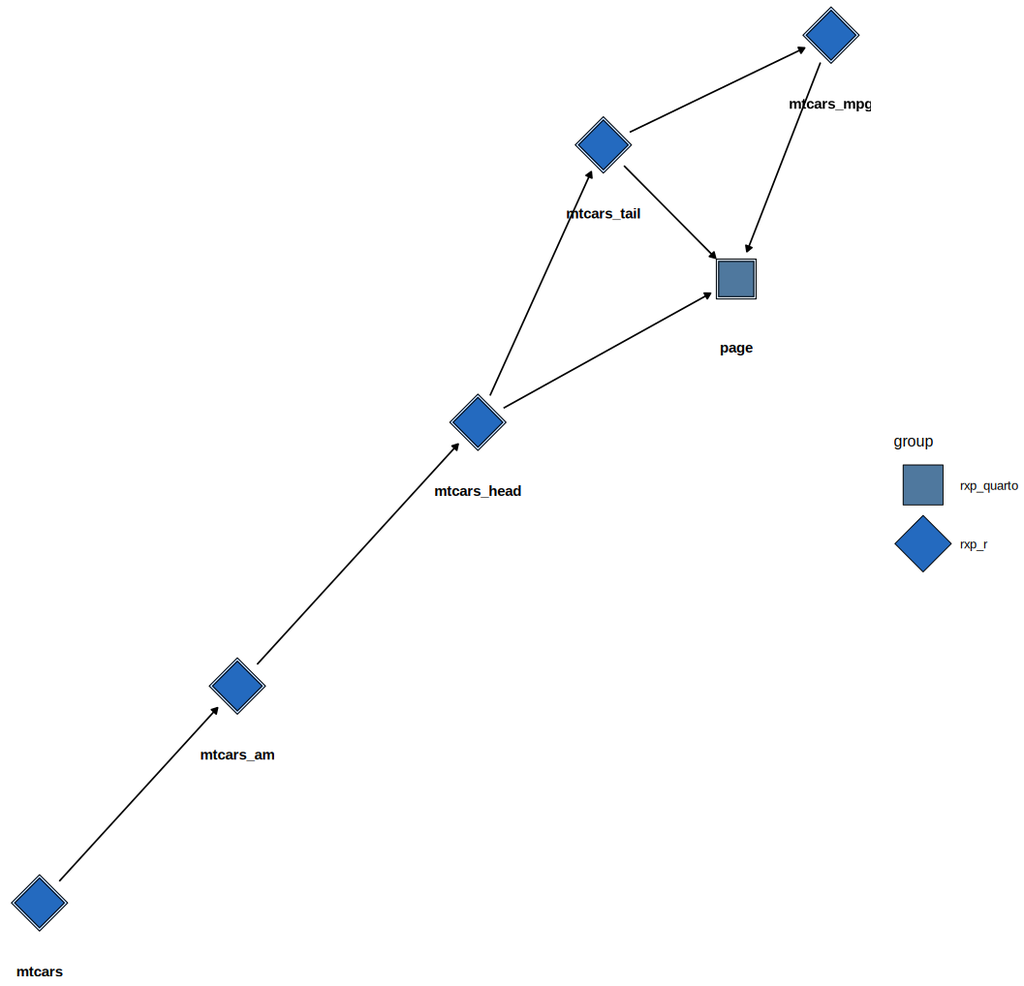

DAG

```r
# ggdag-based static plot
rxp_ggdag()
```

```r
# Interactive network (visNetwork)
rxp_visnetwork()
```

To create an artifact suitable for CI, use:

```r
rxp_dag_for_ci()
```

This will export the directed acyclic graph of the pipeline as a `dot` file, making it possible to visualize in CI (using [`stacked-dag`](https://hackage.haskell.org/package/stacked-dag) for example).

## Exporting / Importing Artifacts

Speed up continuous integration or move a cache between machines:

```r
# Export build products
rxp_export_artifacts()

# Import elsewhere before building
rxp_import_artifacts()
```

## Contributing

Pull requests are welcome. If you’re unsure whether to open one, feel free to open an issue first to discuss your idea. For contributor guidelines, see CONTRIBUTING.md.

If you plan to contribute documentation or vignettes, please:

- Add runnable, minimal examples.
- Prefer small datasets and short-running examples.
- Document required system dependencies for the example (through a `default.nix`).

Please note that this package is released with a [Contributor Code of Conduct](https://ropensci.org/code-of-conduct/). By contributing to this project, you agree to abide by its terms.

## Scope

Please refer to the `vignette("scope")` to learn more about what `{rixpress}` will and will not support.

## Acknowledgements

- Inspired by the design and ergonomics of `{targets}`.
- Built atop the reproducibility foundations provided by `{rix}` and the ‘Nix’ ecosystem.
- rOpenSci peer review contributors and reviewers for feedback that shaped the interface.